# Examining prediction accuracy as a consequence of effect sizes estimated in the discovery vs an independent sample

# Introduction

We were seeing that prediction accuracy, measured as the correlation between the polygenic score and genetic value, was much higher (~2x) when the variants were discovered in one sample (N = 9K) but the effects were re-estimated in siblings (N = 9k). This prediction accuracy was even higher than a fully siblig gwas (also 9k) where presumably the effects are more unbiased (not as impacted by stratification).

We think this may have something to do with winner’s curse or the fact that the increase in accuracy is due to the fact that the effects are re-estimated in an independent sample. To test this, let’s ignore the siblings and calculate PRS in two ways:

1. effects estimated in the discovery sample (this is what is normally done).
2. variants discovered in a GWAS in unrelated individuals and effects re-estimated in an independent sample.

Let’s calculate both bias and prediction accuracy in both ways.

```r
library(ggplot2)
library(data.table)
library(dplyr)
library(rprojroot)
library(patchwork)
F = is_rstudio_project$make_fix_file()
```

Question: What is the accuracy of polygenic risk prediction when we re-estimate effects in the same sample as the discovery set?

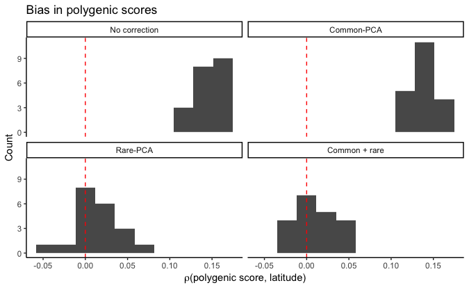

```r
#effects discovered and estimated in training set and
#prs predicted in 3rd set (used to construct sibling haplotypes)
prs1 = fread(F("gwas/grid/genotypes/tau100/ss500/revisions/prs_prediction/prs1sample/prs.smooth.a1_p3.all.nc.sscore"))
colnames(prs1) = c("rep","IID","pcs0","cm","re","cmre")
mprs1 = reshape2::melt(prs1,id.vars = c("rep","IID"),
                       value.name = "prs",
                       variable.name = "correction")
#load genetic values for individuals in the sample we are predicting - to calculate prediction accuracy
gvalue1 = fread(F("gwas/grid/genotypes/tau100/ss500/revisions/prs_prediction/gvalues/gvalue.p3.all.sscore"))
colnames(gvalue1) = c("rep","IID","gvalue")
#load latitude information - to calculate bias
pop1 = fread(F("gwas/grid/genotypes/tau100/ss500/iid_sib.txt"))
#add latitude info
mprs1 = merge(mprs1, pop1, by="IID")
#add genetic value
mprs1 = merge(mprs1, gvalue1, by=c("rep","IID"))
#center the prs and subtract out genetic value
mprs1 = mprs1%>%
  group_by(rep,correction)%>%
  mutate(prs.adjusted = prs - mean(prs),
         prs.adjusted = prs.adjusted - gvalue)
#calculate the bias and prediction accuracy
mprs1.bias = mprs1 %>%
  group_by(rep,correction)%>%
  summarize(rlat = cor(prs,latitude),
            r2 = cor(prs,gvalue)^2)
plt_bias.all = ggplot(mprs1.bias,aes(rlat))+
  geom_histogram(bins=10)+
  facet_wrap( ~ correction,
              labeller = as_labeller(c(
                pcs0 = "No correction",
                cm = "Common-PCA",
                re = "Rare-PCA",
                cmre = "Common + rare"
              )))+
  theme_classic()+
  labs(x = bquote(rho*"(polygenic score, latitude)"),
       y = "Count",
       title = "Bias in polygenic scores")+
  geom_vline(xintercept=0,color="red",linetype="dashed")
plt_bias.all
```

Rare variants more appropriately correct for stratification, that much we already knew. Let’s just get the plot for “no correction”, which is what we need.

```r
plt1.bias = ggplot(mprs1.bias%>%
                     filter(correction=="pcs0"),
                   aes(rlat))+
  geom_histogram()+
  theme_classic()+
  labs(x = bquote(rho*"(polygenic score, latitude)"),
       y = "Count",
       title = "Bias")
```

Now plot the prediction accuracy when effect estimation and discovery in done in the sample.

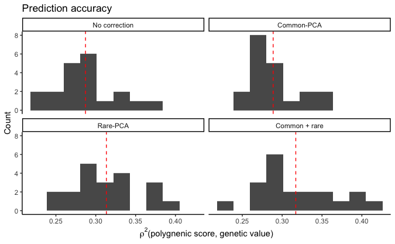

```r
#calculate mean prediction accuracy across replicates
mprs1.bias.mean = mprs1.bias%>%
  group_by(correction)%>%
  summarize(rlat = mean(rlat),
            r2 = mean(r2))
plt1.r2 = ggplot(mprs1.bias,
                 aes(r2))+
  geom_histogram(bins=10)+
  theme_classic()+
  geom_vline(data=mprs1.bias.mean,
             aes(xintercept = r2),
             color="red",
             linetype="dashed")+
facet_wrap( ~ correction,
              labeller = as_labeller(c(
                pcs0 = "No correction",
                cm = "Common-PCA",
                re = "Rare-PCA",
                cmre = "Common + rare"
              )))+
  labs(x = bquote(rho^2*"(polygnenic score, genetic value)"),
       y = "Count",
       title = "Prediction accuracy")
plt1.r2
```

Now, let’s plot both bias and prediction accuracy if we ascertain variants in one sample and re-estimate in another.

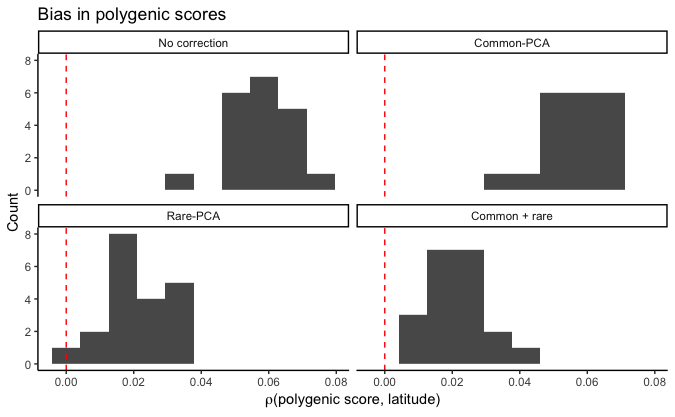

```r
prs2 = fread(F("gwas/grid/genotypes/tau100/ss500/revisions/prs_prediction/prs/a1_r2_p3.smooth.pcs0.all.sscore"))
colnames(prs2) = c("rep","IID","pcs0","cm","re","cmre")
mprs2 = reshape2::melt(prs2,id.vars = c("rep","IID"),
                       value.name = "prs",
                       variable.name = "correction")
#load genetic values for individuals in the sample we are predicting - to calculate prediction accuracy
#same as the gvalue1
#add latitude info
mprs2 = merge(mprs2, pop1, by="IID")
#add genetic value
mprs2 = merge(mprs2, gvalue1, by=c("rep","IID"))
#center the prs and subtract out genetic value
mprs2 = mprs2%>%
  group_by(rep,correction)%>%
  mutate(prs.adjusted = prs - mean(prs),
         prs.adjusted = prs.adjusted - gvalue)
#calculate the bias and prediction accuracy
mprs2.bias = mprs2 %>%
  group_by(rep,correction)%>%
  summarize(rlat = cor(prs,latitude),
            r2 = cor(prs,gvalue)^2)
plt_bias.all = ggplot(mprs2.bias,aes(rlat))+
  geom_histogram(bins=10)+
  facet_wrap( ~ correction,
              labeller = as_labeller(c(
                pcs0 = "No correction",
                cm = "Common-PCA",
                re = "Rare-PCA",
                cmre = "Common + rare"
              )))+
  theme_classic()+
  labs(x = bquote(rho*"(polygenic score, latitude)"),
       y = "Count",
       title = "Bias in polygenic scores")+
  geom_vline(xintercept=0,color="red",linetype="dashed")
plt_bias.all
```

The bias is much smaller when the effects are re-estimated. Now plot the prediction accuracy.

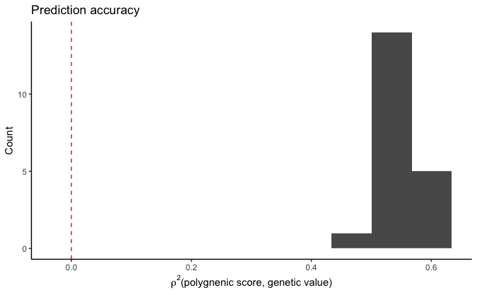

```r
plt2.bias = ggplot(mprs2.bias%>%
                     filter(correction=="pcs0"),
                   aes(rlat))+
  geom_histogram()+
  theme_classic()+
  labs(x = bquote(rho*"(polygenic score, latitude)"),
       y = "Count",
       title = "Bias")
#calculate mean prediction accuracy across replicates
mprs2.bias.mean = mprs2.bias%>%
  group_by(correction)%>%
  summarize(rlat = mean(rlat),
            r2 = mean(r2))
plt2.r2 = ggplot(mprs2.bias%>%
                   filter(correction=="pcs0"),
                 aes(r2))+
  geom_histogram(bins=10)+
  geom_vline(xintercept=0,color="red",linetype="dashed")+
  theme_classic()+
  labs(x = bquote(rho^2*"(polygnenic score, genetic value)"),
       y = "Count",
       title = "Prediction accuracy")
plt2.r2
```

The prediction accuracy is much higher when effects are re-estimated in a different sample.

Now let’s look at these plots when we discover and estimate effects in the sample but with a size twice the original sample. The question being: is the increase in prediction accuracy when we re-estimate an effect of re-estimation or due to an increase in sample size.

```r
prs.combined = fread(F("gwas/grid/genotypes/tau100/ss500/revisions/combined_sample/prs/gridt100_prs_smooth.combined.all.nc.sscore"))
colnames(prs.combined) = c("rep","IID","prs")
prs.combined = merge(prs.combined,
                     gvalue1,
                     by=c("rep","IID"))
prs.combined = merge(prs.combined,pop1,by="IID")
prs.combined$ascertainment = "2x sample size"
#center the prs and subtract out genetic value
prs.combined = prs.combined%>%
  group_by(rep)%>%
  mutate(prs.adjusted = prs - mean(prs),
         prs.adjusted = prs.adjusted - gvalue)
#calculate the bias and prediction accuracy
prs.combined.bias = prs.combined %>%
  group_by(rep)%>%
  summarize(rlat = cor(prs,latitude),
            r2 = cor(prs,gvalue)^2)
prs.combined.bias$ascertainment = "2x sample size"
```

[figure not shown]

```r
plt_bias.combined = ggplot(prs.combined.bias,
                           aes(rlat))+
  geom_histogram()+
  theme_classic()+
  labs(x = bquote(rho*"(polygenic score, latitude)"),
       y = "Count",
       title = "Bias in polygenic scores")

plt_bias.combined

plt_r2.combined = ggplot(prs.combined.bias,
                           aes(r2))+
  geom_histogram()+
  theme_classic()+
  labs(x = bquote(rho*"(polygenic score, latitude)"),
       y = "Count",
       title = "Prediction accuracy")

plt_r2.combined
```